# Una materia de ingeniería completamente en Jupyter

© 2021 Víctor A. Bettachini  
Mecánica General  
Departamento de Ingeniería e Investigación Tecnológica  
Universidad Nacional de La Matanza

# Ingeniería Mecánica en la UNLaM

[figure not shown]

# Mecánica General y correlativas

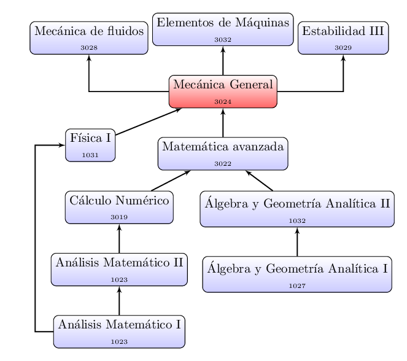

# Mecánica General: entre básicas y específicas

- **Interfaz** $\implies$ instrumentar lo visto en básicas
- Practicar herramientas analíticas aplicables en máquinas, estabilidad y fluidos
- Plan: describir la dinámica de sistemas mecánicos simples
  - Modelizar $\implies$ simplificar la física
  - Relacionar analíticamente elementos del modelo
  - Obtener una ecuación diferencial de su dinámica
  - **Identificar implicaciones ingenieriles**
- ¿Cómo lograr esto? Con mucha matemática pues vienen de cursar
  - **Análisis** y **Álgebras**
    - lo que no usan pronto, se olvida
  - **Cálculo Numérico**
    - lo que no se aplica en algo de interés, se desprecia.
  - Lo aprendido **aplicarlo pronto a sistemas mecánicos**

# ¿Cómo se suele plantear la materia?

# 1972: La regla de cálculo y la calculadora

[figure not shown]

# 2021: La computadora en clase, ¿para pasar "diapositivas"?

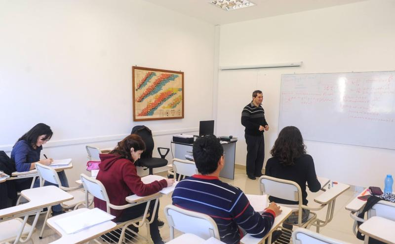

# Aún las "diapositivas" pueden mejorarse

Pueden hacerse interactivas.

FrequencyBeatings.ipynb

https://github.com/prandoni/COM303/blob/master/FrequencyBeatings/FrequencyBeatings.ipynb

# Y esto se alienta por autoridades universitarias

[figure not shown]

# Clase 1 | El péndulo ideal

**Ecuaciones claras con $\LaTeX$**

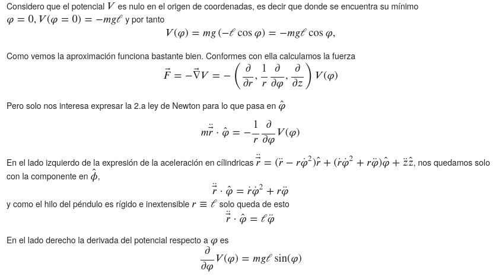

# Y gráficos claros

En vez de ocultar el usa de código, se lo muestra para animar a la imitación.

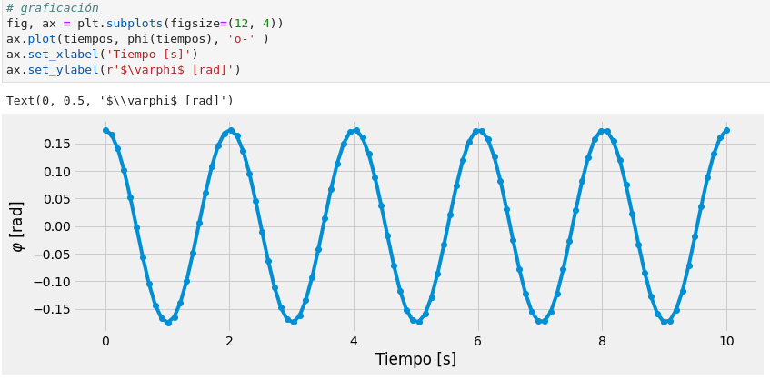

# Clase 3 | Cálculo simbólico

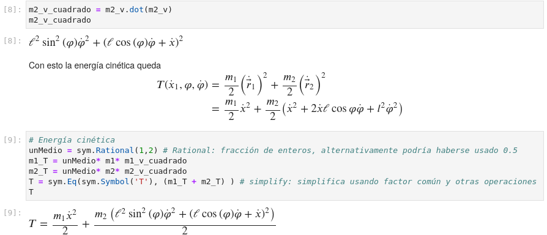

# Clase 5 | Y hasta acá se suele llegar en pizarrón

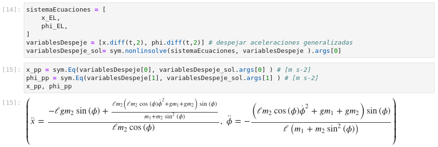

# Pero cursaron "numérico" y están frente a una computadora...

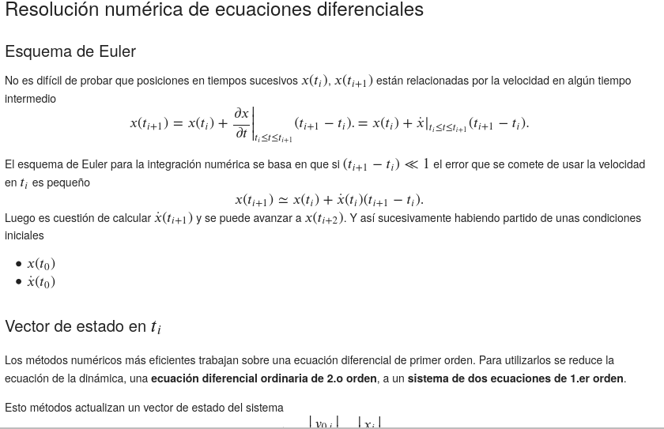

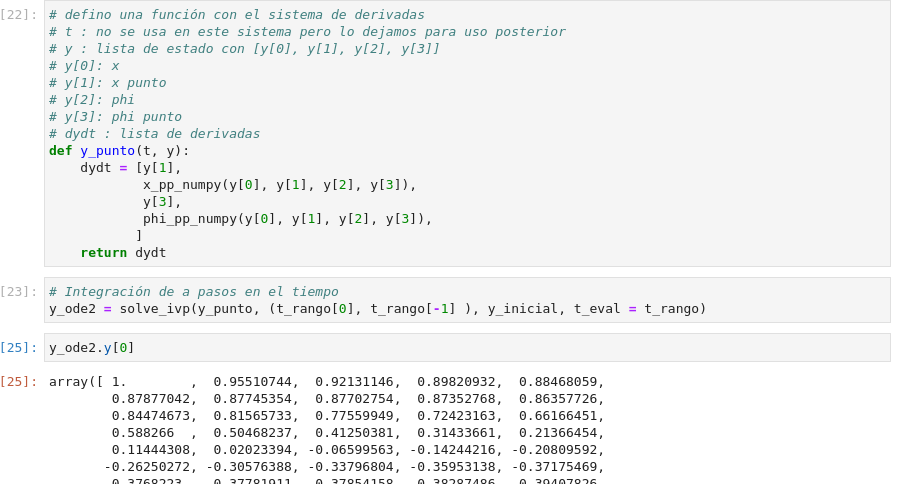

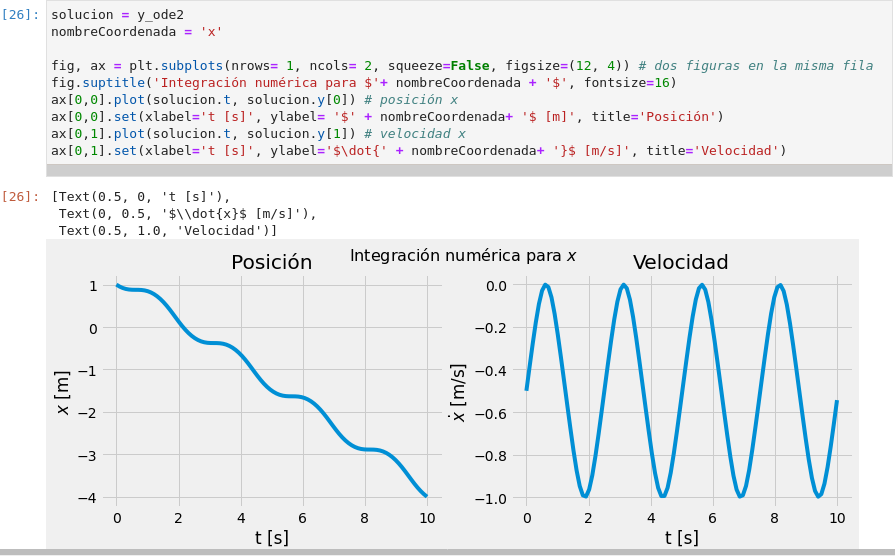

# Clase 11 | Sistemas oscilatorios amortiguados

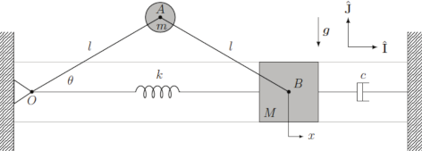

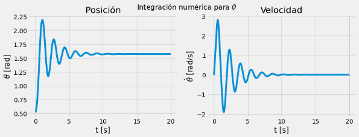

# Se pueden implementar otras simulaciones

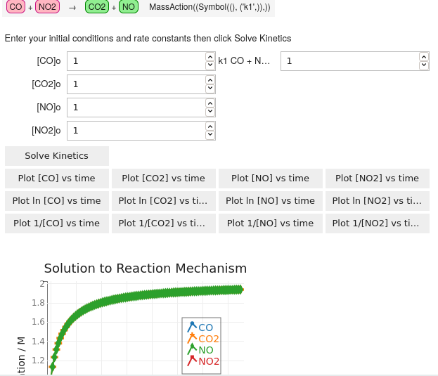

https://chemcompute.org/simulations/submit/Rate+Limiting+Step+Approximation

# ¿Qué puede incluirse en un cuaderno de Jupyter?

- Imágenes, video, sonido y enlaces web
- Texto y ecuaciones con símbolos $\LaTeX$
- Código ejecutable en muchos lenguajes (Python, C, R, etc.)
  - Gráficos estáticos y animaciones
  - Cálculo simbólico y numérico
  - Modelos interactivos

# Bibliografía

[1] L. Barba et al., Teaching and Learning with Jupyter. George Washington University, 28–30 November 2018, Disponible en: https://jupyter4edu.github.io/jupyter-edu-book/

[2] E. Díaz García y E. Cabrera Granado, «Manual de uso de Jupyter Notebook para aplicaciones docentes», 2018. https://eprints.ucm.es/id/eprint/48304/